# Tuning_Optuna_models

#### Boosting alghoritms and Hyperparameters tuning using k-fold cross validation

##### First alghorithm: LightGBM

```python
def objective(trial):
    #
    X_train, X_test, y_train, y_test = train_test_split(X, y, test_size=0.2, random_state=1)  # Splits the dataset into train and test sets with an 80-20 split.
    XX = pd.get_dummies(pd.concat([X_train, X_test], sort=False))  # Concatenates train and test sets to create dummy variables for all categorical features.
    X_train, X_test = XX.loc[X_train.index], XX.loc[X_test.index]  # Restores the train and test sets based on their original indices.

    X_train = clean_feature_names(X_train)  # Cleans the feature names in the training set.
    X_test = clean_feature_names(X_test)  # Cleans the feature names in the test set.

    X_train, X_test = X_train.align(X_test, join='inner', axis=1)  # Aligns train and test sets to ensure they have the same columns.

    scale_pos_weight = len(y[y == 0]) / len(y[y == 1])  # Calculates the positive class weight to handle class imbalance.

    # Defines the hyperparameters for LightGBM.
    params = {
        'n_estimators': trial.suggest_int('n_estimators', 100, 300),  # Number of trees in the model.
        'learning_rate': trial.suggest_loguniform('learning_rate', 0.001, 0.2),  # Learning rate to shrink the contribution of each tree.
        'max_depth': trial.suggest_int('max_depth', 5, 15),  # Maximum depth of the tree.
        'num_leaves': trial.suggest_int('num_leaves', 20, 40),  # Maximum number of leaves per tree.
        'min_child_samples': trial.suggest_int('min_child_samples', 10, 50),  # Minimum number of samples a node must have to be split.
        'subsample': trial.suggest_float('subsample', 0.8, 1.0),  # Fraction of data to be used for fitting each tree.
        'subsample_freq': trial.suggest_int('subsample_freq', 0, 7),  # Frequency of subsampling.
        'colsample_bytree': trial.suggest_float('colsample_bytree', 0.6, 1.0),  # Fraction of features to be used for fitting each tree.
        'reg_alpha': trial.suggest_float('reg_alpha', 0.0, 1.0),  # L1 regularization term to prevent overfitting.
        'reg_lambda': trial.suggest_float('reg_lambda', 0.0, 1.0),  # L2 regularization term to prevent overfitting.
        'max_bin': trial.suggest_int('max_bin', 200, 300),  # Maximum number of bins to bucket continuous features.
        'scale_pos_weight': scale_pos_weight,  # Weight for the positive class to handle imbalance.
        'force_col_wise': True,  # Forces LightGBM to use column-wise data format.
        'verbosity': -1  # Sets the verbosity level (silent mode).
    }

    kf = StratifiedKFold(n_splits=10, shuffle=True, random_state=42)  # Stratified K-Fold cross-validation to maintain class proportions in each fold.
    scores = []

    for train_index, val_index in kf.split(X_train, y_train):
        X_fold_train, X_fold_val = X_train.iloc[train_index], X_train.iloc[val_index]  # Splits the train set into training and validation folds.
        y_fold_train, y_fold_val = y_train.iloc[train_index], y_train.iloc[val_index]  # Splits the labels correspondingly.

        model = lgb.LGBMClassifier(**params)  # Initializes the LightGBM model with the defined hyperparameters.
        model.fit(X_fold_train, y_fold_train)  # Trains the model on the training fold.
        probas = model.predict_proba(X_fold_val)[:, 1]  # Predicts probabilities for the validation fold.
        top_indices = np.argsort(probas)[-1698:]  # Sorts probabilities in descending order and selects the top 1698 (about 1/6 of the total).
        top_positives = y_fold_val.iloc[top_indices].sum()  # Counts the number of positive classes in the top 1698.
        total_positives = y_fold_val.sum()  # Counts the total number of positive classes in the validation fold.
        scores.append(top_positives / total_positives if total_positives > 0 else 0)  # Calculates the ratio of top positives to total positives and appends to scores list.

    return np.mean(scores)  # Returns the mean score across all folds.

sampler = optuna.samplers.TPESampler(seed=42)  # Initializes the TPE Sampler for Bayesian optimization with Optuna.
study = optuna.create_study(direction='maximize', sampler=sampler)  # Creates an Optuna study to maximize the objective function.
study.optimize(objective, n_trials=50)  # Optimizes the objective function for 50 trials.

best_params = study.best_params  # Retrieves the best hyperparameters found.
best_score = study.best_value  # Retrieves the best score achieved.

print("Best Hyperparameters:", best_params)
print("Best Score for Top 50,000:", best_score)

history_plot = vis.plot_optimization_history(study)  # Creates a plot of the optimization history.
history_plot.show()

importance_plot = vis.plot_param_importances(study)  # Creates a plot of hyperparameter importances.
importance_plot.show()

slice_plot = vis.plot_slice(study)  # Creates a slice plot to visualize hyperparameter effects.
slice_plot.show()
```

```
[I 2024-05-08 12:15:57,068] A new study created in memory with name: no-name-5abef84b-4e23-411d-bd4b-ab4aeb0715d4
[I 2024-05-08 12:16:27,553] Trial 0 finished with value: 0.33333333333333337 and parameters: {'n_estimators': 175, 'learning_rate': 0.1540359659501924, 'max_depth': 13, 'num_leaves': 32, 'min_child_samples': 16, 'subsample': 0.8311989040672406, 'subsample_freq': 0, 'colsample_bytree': 0.946470458309…
[I 2024-05-08 12:17:12,002] Trial 1 finished with value: 0.4320754716981132 and parameters: {'n_estimators': 294, 'learning_rate': 0.0823143373099555, 'max_depth': 7, 'num_leaves': 23, 'min_child_samples': 17, 'subsample': 0.8608484485919076, 'subsample_freq': 4, 'colsample_bytree': 0.77277800745684…
[I 2024-05-08 12:17:46,216] Trial 2 finished with value: 0.5283018867924529 and parameters: {'n_estimators': 158, 'learning_rate': 0.006966418981413735, 'max_depth': 10, 'num_leaves': 36, 'min_child_samples': 18, 'subsample': 0.9028468876827224, 'subsample_freq': 4, 'colsample_bytree': 0.61858016508…
[I 2024-05-08 12:18:27,362] Trial 3 finished with value: 0.2358490566037736 and parameters: {'n_estimators': 290, 'learning_rate': 0.16670486450654684, 'max_depth': 13, 'num_leaves': 26, 'min_child_samples': 14, 'subsample': 0.9368466053024314, 'subsample_freq': 3, 'colsample_bytree': 0.648815293937…
[I 2024-05-08 12:18:57,607] Trial 4 finished with value: 0.5515723270440251 and parameters: {'n_estimators': 152, 'learning_rate': 0.03345674213696821, 'max_depth': 8, 'num_leaves': 30, 'min_child_samples': 32, 'subsample': 0.8369708911051055, 'subsample_freq': 7, 'colsample_bytree': 0.9100531293444…
[I 2024-05-08 12:19:45,062] Trial 5 finished with value: 0.5232704402515722 and parameters: {'n_estimators': 285, 'learning_rate': 0.0015981734133214873, 'max_depth': 7, 'num_leaves': 20, 'min_child_samples': 23, 'subsample': 0.8777354579378964, 'subsample_freq': 2, 'colsample_bytree': 0.93149500366…
[I 2024-05-08 12:20:06,533] Trial 6 finished with value: 0.4817610062893082 and parameters: {'n_estimators': 128, 'learning_rate': 0.07012604000905365, 'max_depth': 5, 'num_leaves': 40, 'min_child_samples': 41, 'subsample': 0.8397431363068345, 'subsample_freq': 0, 'colsample_bytree': 0.9261845713819…
[I 2024-05-08 12:20:30,334] Trial 7 finished with value: 0.5339622641509434 and parameters: {'n_estimators': 114, 'learning_rate': 0.006680983417211186, 'max_depth': 6, 'num_leaves': 38, 'min_child_samples': 35, 'subsample': 0.8661796049705299, 'subsample_freq': 0, 'colsample_bytree': 0.724392928686…
[I 2024-05-08 12:21:14,917] Trial 8 finished with value: 0.5559748427672957 and parameters: {'n_estimators': 278, 'learning_rate': 0.012206206339370173, 'max_depth': 6, 'num_leaves': 34, 'min_child_samples': 41, 'subsample': 0.9122554395138993, 'subsample_freq': 6, 'colsample_bytree': 0.797518238545…
[I 2024-05-08 12:21:40,466] Trial 9 finished with value: 0.5238993710691824 and parameters: {'n_estimators': 121, 'learning_rate': 0.0011811892859183053, 'max_depth': 12, 'num_leaves': 26, 'min_child_samples': 30, 'subsample': 0.9815132947852186, 'subsample_freq': 1, 'colsample_bytree': 0.7641531692…
[I 2024-05-08 12:22:28,416] Trial 10 finished with value: 0.5616352201257861 and parameters: {'n_estimators': 234, 'learning_rate': 0.0193166886573686, 'max_depth': 15, 'num_leaves': 34, 'min_child_samples': 50, 'subsample': 0.9378862782158467, 'subsample_freq': 7, 'colsample_bytree': 0.849633410868…
[I 2024-05-08 12:23:14,582] Trial 11 finished with value: 0.5672955974842766 and parameters: {'n_estimators': 239, 'learning_rate': 0.018697035617226986, 'max_depth': 10, 'num_leaves': 34, 'min_child_samples': 49, 'subsample': 0.9360366566416916, 'subsample_freq': 7, 'colsample_bytree': 0.8538760284…
[I 2024-05-08 12:23:59,033] Trial 12 finished with value: 0.5572327044025157 and parameters: {'n_estimators': 230, 'learning_rate': 0.024111122363670585, 'max_depth': 15, 'num_leaves': 30, 'min_child_samples': 50, 'subsample': 0.9571667171034628, 'subsample_freq': 6, 'colsample_bytree': 0.8643422901…
```

[output cut: 37 more lines]

```
Best Hyperparameters: {'n_estimators': 218, 'learning_rate': 0.01924315730262365, 'max_depth': 14, 'num_leaves': 39, 'min_child_samples': 25, 'subsample': 0.9614156550100574, 'subsample_freq': 3, 'colsample_bytree': 0.7963352256675209, 'reg_alpha': 0.3944497642389667, 'reg_lambda': 0.550433225178204…
Best Score for Top 50,000: 0.5748427672955975
```

```python
# We stopped the tuning earlier since we found a good set of parameters and tuning wasn't giving us better results but was converging to the same parameters
'''
Best Hyperparameters: {'n_estimators': 218, 'learning_rate': 0.01924315730262365, 'max_depth': 14, 'num_leaves': 39, 'min_child_samples': 25, 'subsample': 0.9614156550100574, 'subsample_freq': 3, 'colsample_bytree': 0.7963352256675209, 'reg_alpha': 0.3944497642389667, 'reg_lambda': 0.5504332251782049, 'max_bin': 245}
'''
scale_pos_weight = len(y[y == 0]) / len(y[y == 1])

best_params = {
    "n_estimators": 218,
    "learning_rate": 0.01924315730262365,
    "max_depth": 14,
    "num_leaves": 39,
    "min_child_samples": 25,
    "subsample": 0.9614156550100574,
    "subsample_freq": 3,
    "colsample_bytree": 0.7963352256675209,
    "reg_alpha": 0.3944497642389667,
    "reg_lambda": 0.5504332251782049,
    "max_bin": 245,
    'force_col_wise': True,
    'scale_pos_weight': scale_pos_weight,
    'verbosity': -1
}

best_lgb_classifier = lgb.LGBMClassifier(**best_params)
best_lgb_classifier.fit(X_train_final, y_train_final)
lgbm_predictions = best_lgb_classifier.predict_proba(X_test_final)[:, 1]
```

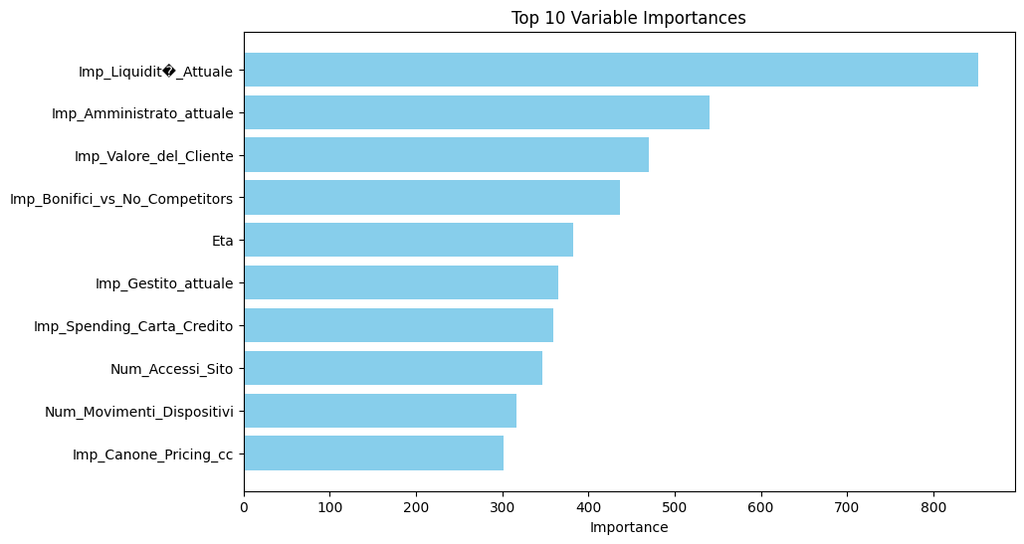

```python
# Get feature importances
importance = best_lgb_classifier.feature_importances_

# Summarize feature importances
features = X_train_final.columns
importance_df = pd.DataFrame({'Feature': features, 'Importance': importance})
importance_df = importance_df.sort_values(by='Importance', ascending=False)

# Plot feature importances
plt.figure(figsize=(10, 6))
plt.barh(importance_df['Feature'].head(10), importance_df['Importance'].head(10), color='skyblue')
plt.xlabel('Importance')
plt.title('Top 10 Variable Importances')
plt.gca().invert_yaxis()
plt.show()
```

```python
results_df = pd.DataFrame({
    'y_test': y_test_final,
    'y_pred_proba': lgbm_predictions

})

results_df_si = results_df
results_df_si_sorted = results_df_si.sort_values(by='y_pred_proba', ascending=False)
top_10000_si = results_df_si_sorted.head(4000)
print(top_10000_si)
```

```
        y_test  y_pred_proba
213385       0      0.983352
117218       0      0.970075
236314       0      0.965924
368493       0      0.963616
17725        1      0.962025
...        ...           ...
108175       0      0.753052
146156       0      0.753014
4891         0      0.753010
193272       0      0.752994
246831       0      0.752976

[4000 rows x 2 columns]
```

```python
count_si = top_10000_si[top_10000_si['y_test'] == 1].shape[0]

print("Numero di 'SI' nei nostri 10k:", count_si)
count_ones = np.sum(y_test == 1)

print("Numero di 'SI: nel nostro test set", count_ones)
```

```
Numero di 'SI' nei nostri 10k: 238
Numero di 'SI: nel nostro test set 393
```

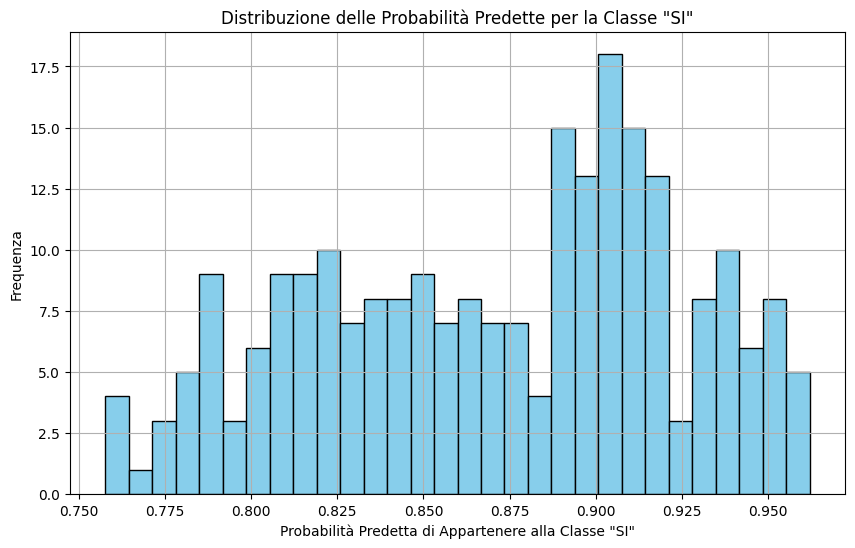

```python
plt.figure(figsize=(10, 6))
plt.hist( top_10000_si[top_10000_si['y_test'] == 1]['y_pred_proba'], bins=30, color='skyblue', edgecolor='black')
plt.title('Distribuzione delle Probabilità Predette per la Classe "SI"')
plt.xlabel('Probabilità Predetta di Appartenere alla Classe "SI"')
plt.ylabel('Frequenza')
plt.grid(True)
plt.show()
```

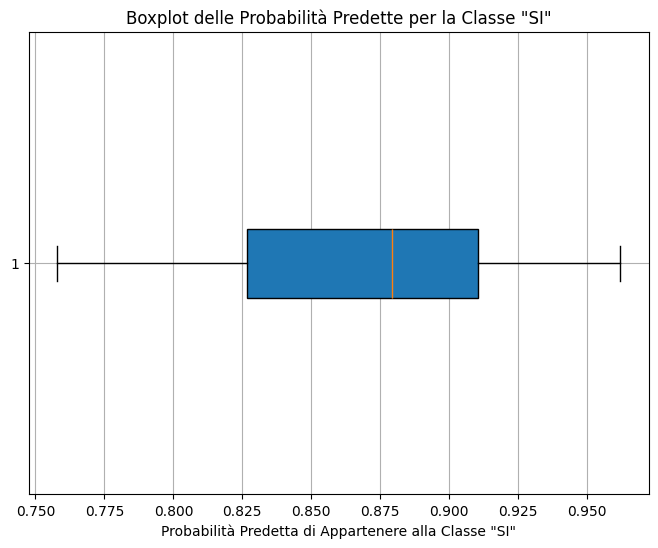

```python
plt.figure(figsize=(8, 6))
plt.boxplot( top_10000_si[top_10000_si['y_test'] == 1]['y_pred_proba'],vert=False, patch_artist=True)
plt.title('Boxplot delle Probabilità Predette per la Classe "SI"')
plt.xlabel('Probabilità Predetta di Appartenere alla Classe "SI"')
plt.grid(True)
plt.show()
```

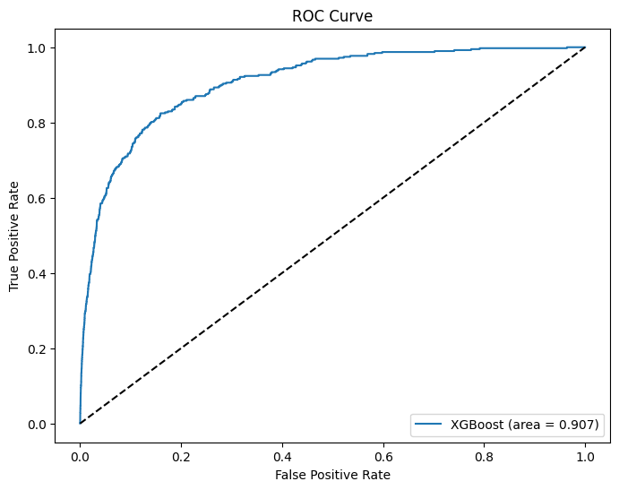

```python
fpr, tpr, thresholds = roc_curve(y_test_final, lgbm_predictions)
auc = roc_auc_score(y_test_final, lgbm_predictions)

plt.figure(figsize=(8, 6))
plt.plot(fpr, tpr, label='XGBoost (area = {:.3f})'.format(auc))
plt.plot([0, 1], [0, 1], 'k--')
plt.xlabel('False Positive Rate')
plt.ylabel('True Positive Rate')
plt.title('ROC Curve')
plt.legend(loc='lower right')
plt.show()
```

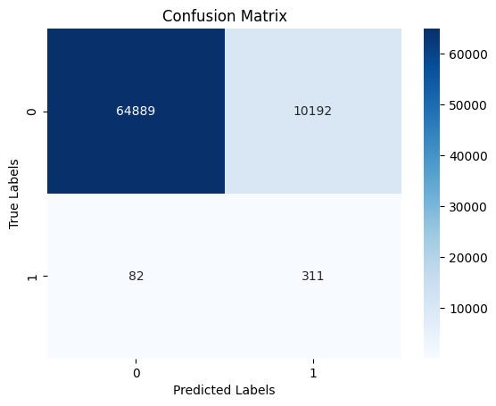

```python
y_pred = best_lgb_classifier.predict(X_test_final)

cm = confusion_matrix(y_test_final, y_pred)
sns.heatmap(cm, annot=True, fmt="d", cmap='Blues')
plt.xlabel('Predicted Labels')
plt.ylabel('True Labels')
plt.title('Confusion Matrix')
plt.show()
```

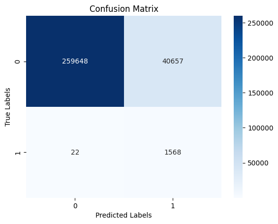

```python
# Train
y_pred = best_lgb_classifier.predict(X_train_final)

cm = confusion_matrix(y_train_final, y_pred)
sns.heatmap(cm, annot=True, fmt="d", cmap='Blues')
plt.xlabel('Predicted Labels')
plt.ylabel('True Labels')
plt.title('Confusion Matrix')
plt.show()
```

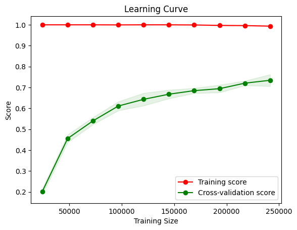

```python
train_sizes, train_scores, test_scores = learning_curve(best_lgb_classifier, X_train, y_train, cv=5, scoring='recall', n_jobs=-1, train_sizes=np.linspace(0.1, 1.0, 10))
train_mean = np.mean(train_scores, axis=1)
train_std = np.std(train_scores, axis=1)
test_mean = np.mean(test_scores, axis=1)
test_std = np.std(test_scores, axis=1)

plt.fill_between(train_sizes, train_mean - train_std, train_mean + train_std, color='r', alpha=0.1)
plt.fill_between(train_sizes, test_mean - test_std, test_mean + test_std, color='g', alpha=0.1)
plt.plot(train_sizes, train_mean, 'o-', color='r', label='Training score')
plt.plot(train_sizes, test_mean, 'o-', color='g', label='Cross-validation score')
plt.xlabel('Training Size')
plt.ylabel('Score')
plt.title('Learning Curve')
plt.legend(loc="best")
plt.show()
```

###### The gap between them does not appear to be widening as the training size increases. This suggests that the model is not severely overfitting, as the cross-validation score is improving . The model should be able to generalize on new unseen data, let's see in practice:

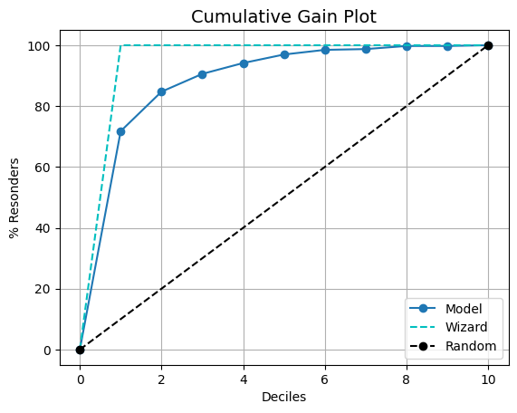

```python
import kds
kds.metrics.plot_cumulative_gain(y_test_final, lgbm_predictions)
```

##### LightGBM on the syntetic dataset

```python
lgbm_predictions = best_lgb_classifier.predict_proba(X_train_res_synthetic)[:, 1] #prediction sul dataset sintetico (intero), rinominato 'erroneamente' come train
results_df = pd.DataFrame({
    'y_test': y_synthetic,
    'y_pred_proba': lgbm_predictions

})

results_df_si = results_df
results_df_si_sorted = results_df_si.sort_values(by='y_pred_proba', ascending=False)
top_10000_si_synthetic = results_df_si_sorted.head(10000)
print(top_10000_si_synthetic)
```

```
       y_test  y_pred_proba
38165       0      0.975087
47139       0      0.973162
20410       0      0.972024
40049       0      0.962809
40234       0      0.955535
...       ...           ...
63189       0      0.399658
23077       0      0.399657
54638       0      0.399580
57098       0      0.399536
44251       0      0.399428

[10000 rows x 2 columns]
```

```python
count_si = top_10000_si_synthetic[top_10000_si_synthetic['y_test'] == 1].shape[0]

print("Numero di 'SI' nei nostri 10k:", count_si)
count_ones = np.sum(y_synthetic == 1)

print("Numero di 'SI: nel nostro test set", count_ones)
```

```
Numero di 'SI' nei nostri 10k: 188
Numero di 'SI: nel nostro test set 489
```

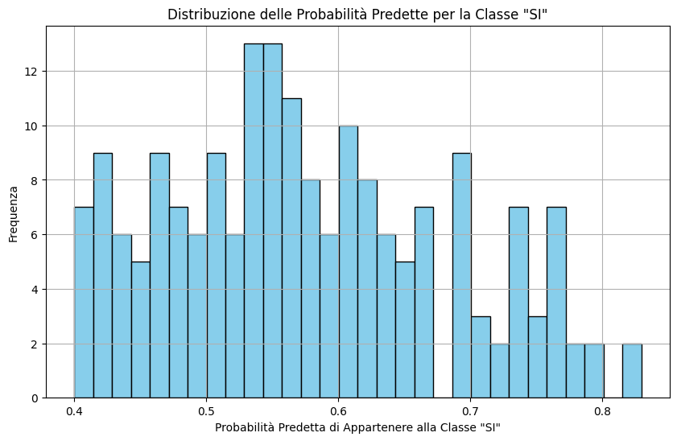

```python
plt.figure(figsize=(10, 6))
plt.hist( top_10000_si_synthetic[top_10000_si_synthetic['y_test'] == 1]['y_pred_proba'], bins=30, color='skyblue', edgecolor='black')
plt.title('Distribuzione delle Probabilità Predette per la Classe "SI"')
plt.xlabel('Probabilità Predetta di Appartenere alla Classe "SI"')
plt.ylabel('Frequenza')
plt.grid(True)
plt.show()
```

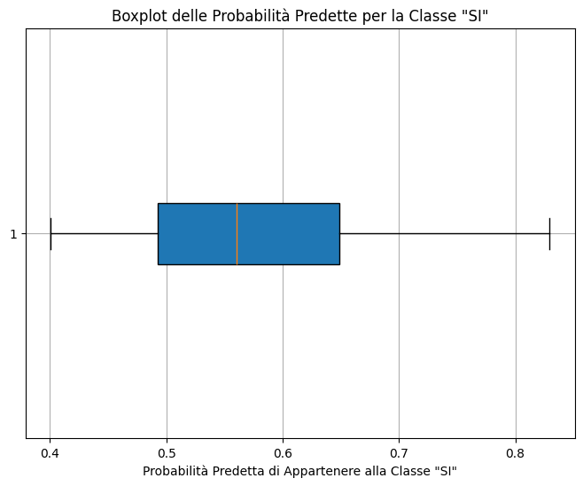

```python
plt.figure(figsize=(8, 6))
plt.boxplot( top_10000_si_synthetic[top_10000_si_synthetic['y_test'] == 1]['y_pred_proba'],vert=False, patch_artist=True)
plt.title('Boxplot delle Probabilità Predette per la Classe "SI"')
plt.xlabel('Probabilità Predetta di Appartenere alla Classe "SI"')
plt.grid(True)
plt.show()
```

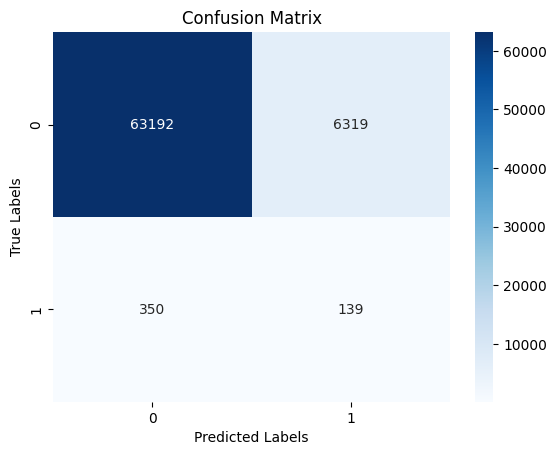

```python
y_pred = best_lgb_classifier.predict(X_train_res_synthetic)

cm = confusion_matrix(y_synthetic, y_pred)
sns.heatmap(cm, annot=True, fmt="d", cmap='Blues')
plt.xlabel('Predicted Labels')
plt.ylabel('True Labels')
plt.title('Confusion Matrix')
plt.show()
```

##### Second Algorithm: XGBoost

```python
def objective(trial):
    X_train, X_test, y_train, y_test = train_test_split(X, y, test_size=0.2, random_state=1)
    XX = pd.get_dummies(pd.concat([X_train, X_test], sort=False))
    X_train, X_test = XX.loc[X_train.index], XX.loc[X_test.index]

    X_train = clean_feature_names(X_train)
    X_test = clean_feature_names(X_test)

    X_train, X_test = X_train.align(X_test, join='inner', axis=1)

    scale_pos_weight = len(y[y == 0]) / len(y[y == 1])
    params = {
        'n_estimators': trial.suggest_int('n_estimators', 100, 1000),
        'learning_rate': trial.suggest_loguniform('learning_rate', 0.01, 0.5),
        'max_depth': trial.suggest_int('max_depth', 3, 10),
        'min_child_weight': trial.suggest_int('min_child_weight', 1, 10),
        'subsample': trial.suggest_float('subsample', 0.5, 1.0),
        'colsample_bytree': trial.suggest_float('colsample_bytree', 0.5, 1.0),
        'gamma': trial.suggest_float('gamma', 0, 5),
        'reg_alpha': trial.suggest_float('reg_alpha', 0, 5),
        'reg_lambda': trial.suggest_float('reg_lambda', 0.1, 10),
        'scale_pos_weight': scale_pos_weight,
        'verbosity': 0
    }

    kf = StratifiedKFold(n_splits=10, shuffle=True, random_state=42)
    scores = []

    for train_index, val_index in kf.split(X_train, y_train):
        X_fold_train, X_fold_val = X_train.iloc[train_index], X_train.iloc[val_index]
        y_fold_train, y_fold_val = y_train.iloc[train_index], y_train.iloc[val_index]

        model = xgb.XGBClassifier(**params)
        model.fit(X_fold_train, y_fold_train)
        probas = model.predict_proba(X_fold_val)[:, 1]
        top_indices = np.argsort(probas)[-1698:]
        top_positives = y_fold_val.iloc[top_indices].sum()
        total_positives = y_fold_val.sum()
        scores.append(top_positives / total_positives if total_positives > 0 else 0)

    return np.mean(scores)

sampler = optuna.samplers.TPESampler(seed=42)
study = optuna.create_study(direction='maximize', sampler=sampler)
study.optimize(objective, n_trials=50)

best_params = study.best_params
best_score = study.best_value

print("Best Hyperparameters:", best_params)
print("Best Score for Top 50,000:", best_score)


history_plot = vis.plot_optimization_history(study)
history_plot.show()

importance_plot = vis.plot_param_importances(study)
importance_plot.show()

slice_plot = vis.plot_slice(study)
slice_plot.show()
```

```
[I 2024-05-08 13:43:00,831] A new study created in memory with name: no-name-56caaa5c-a949-492c-a8a7-4dc5dea2625c
[I 2024-05-08 13:49:27,554] Trial 0 finished with value: 0.44654088050314467 and parameters: {'n_estimators': 437, 'learning_rate': 0.4123206532618726, 'max_depth': 8, 'min_child_weight': 6, 'subsample': 0.5780093202212182, 'colsample_bytree': 0.5779972601681014, 'gamma': 0.2904180608409973, 'reg_al…
[I 2024-05-08 13:59:57,678] Trial 1 finished with value: 0.5333333333333334 and parameters: {'n_estimators': 737, 'learning_rate': 0.01083858126934475, 'max_depth': 10, 'min_child_weight': 9, 'subsample': 0.6061695553391381, 'colsample_bytree': 0.5909124836035503, 'gamma': 0.9170225492671691, 'reg_a…
[I 2024-05-08 14:05:31,171] Trial 2 finished with value: 0.5484276729559749 and parameters: {'n_estimators': 489, 'learning_rate': 0.03124565071260872, 'max_depth': 7, 'min_child_weight': 2, 'subsample': 0.6460723242676091, 'colsample_bytree': 0.6831809216468459, 'gamma': 2.28034992108518, 'reg_alph…
[I 2024-05-08 14:09:36,139] Trial 3 finished with value: 0.5779874213836479 and parameters: {'n_estimators': 563, 'learning_rate': 0.10150667045928574, 'max_depth': 3, 'min_child_weight': 7, 'subsample': 0.5852620618436457, 'colsample_bytree': 0.5325257964926398, 'gamma': 4.7444276862666666, 'reg_al…
[I 2024-05-08 14:14:43,342] Trial 4 finished with value: 0.5553459119496855 and parameters: {'n_estimators': 374, 'learning_rate': 0.01465352103067214, 'max_depth': 8, 'min_child_weight': 5, 'subsample': 0.5610191174223894, 'colsample_bytree': 0.7475884550556351, 'gamma': 0.17194260557609198, 'reg_a…
[I 2024-05-08 14:21:49,156] Trial 5 finished with value: 0.5509433962264151 and parameters: {'n_estimators': 696, 'learning_rate': 0.033852267834519785, 'max_depth': 7, 'min_child_weight': 6, 'subsample': 0.5924272277627636, 'colsample_bytree': 0.9847923138822793, 'gamma': 3.8756641168055728, 'reg_a…
[I 2024-05-08 14:26:13,838] Trial 6 finished with value: 0.5100628930817611 and parameters: {'n_estimators': 638, 'learning_rate': 0.36832964384234185, 'max_depth': 3, 'min_child_weight': 2, 'subsample': 0.522613644455269, 'colsample_bytree': 0.6626651653816322, 'gamma': 1.9433864484474102, 'reg_alp…
[I 2024-05-08 14:30:45,141] Trial 7 finished with value: 0.5528301886792453 and parameters: {'n_estimators': 421, 'learning_rate': 0.030012301808980443, 'max_depth': 7, 'min_child_weight': 2, 'subsample': 0.9010984903770198, 'colsample_bytree': 0.5372753218398854, 'gamma': 4.9344346830025865, 'reg_a…
[I 2024-05-08 14:32:42,848] Trial 8 finished with value: 0.5207547169811321 and parameters: {'n_estimators': 104, 'learning_rate': 0.24290950368254952, 'max_depth': 8, 'min_child_weight': 8, 'subsample': 0.8856351733429728, 'colsample_bytree': 0.5370223258670452, 'gamma': 1.7923286427213632, 'reg_al…
[I 2024-05-08 14:37:20,086] Trial 9 finished with value: 0.5849056603773585 and parameters: {'n_estimators': 661, 'learning_rate': 0.036491004518573594, 'max_depth': 3, 'min_child_weight': 4, 'subsample': 0.6625916610133735, 'colsample_bytree': 0.864803089169032, 'gamma': 3.1877873567760657, 'reg_al…
[I 2024-05-08 14:44:30,783] Trial 10 finished with value: 0.5289308176100629 and parameters: {'n_estimators': 962, 'learning_rate': 0.10083812901315087, 'max_depth': 5, 'min_child_weight': 4, 'subsample': 0.7512656088373982, 'colsample_bytree': 0.925987695633017, 'gamma': 3.2718826138537667, 'reg_al…
[I 2024-05-08 14:49:57,166] Trial 11 finished with value: 0.5660377358490565 and parameters: {'n_estimators': 861, 'learning_rate': 0.09496415760616873, 'max_depth': 3, 'min_child_weight': 8, 'subsample': 0.7171781358782057, 'colsample_bytree': 0.865042426595599, 'gamma': 4.777833521699495, 'reg_alp…
[I 2024-05-08 14:52:41,929] Trial 12 finished with value: 0.5647798742138365 and parameters: {'n_estimators': 240, 'learning_rate': 0.05986930993869558, 'max_depth': 5, 'min_child_weight': 4, 'subsample': 0.7085862143808441, 'colsample_bytree': 0.8263406001124906, 'gamma': 3.5058129769688002, 'reg_a…
```

[output cut: 37 more lines]

```
Best Hyperparameters: {'n_estimators': 779, 'learning_rate': 0.05230683198500739, 'max_depth': 3, 'min_child_weight': 3, 'subsample': 0.6723675387518698, 'colsample_bytree': 0.8481282797708494, 'gamma': 1.0748305640105353, 'reg_alpha': 1.908194383169251, 'reg_lambda': 5.262797824019152}
Best Score for Top 50,000: 0.5874213836477987
```

###### Application on XGBoost of the best hyperparameters chosen by Optuna

```python
import xgboost
'''
Best Hyperparameters: {'n_estimators': 661, 'learning_rate': 0.036491004518573594, 'max_depth': 3, 'min_child_weight': 4, 'subsample': 0.6625916610133735, 'colsample_bytree': 0.864803089169032, 'gamma': 3.1877873567760657, 'reg_alpha': 4.436063712881633, 'reg_lambda': 4.7749277591032975}
Best Score for Top 50,000: 0.829559748427673
'''
# There was a problem with the parameters verbosity, I had to set manually a value in range in main xgboost configuration
xgb.set_config(verbosity=0)
config = xgb.get_config()
assert config['verbosity'] == 0
xgboost.config_context(verbosity=0)
scale_pos_weight = len(y[y == 0]) / len(y[y == 1])
xgb_params = {
    'n_estimators': 779,
    'learning_rate': 0.05230683198500739,
    'max_depth': 3,
    'min_child_weight': 3,
    'subsample': 0.6723675387518698,
    'colsample_bytree': 0.8481282797708494,
    'gamma': 1.0748305640105353,
    'reg_alpha': 1.908194383169251,
    'reg_lambda': 5.262797824019152,
    'scale_pos_weight': scale_pos_weight,
}

best_xgb_classifier = xgb.XGBClassifier(verbosity=0, **xgb_params)

best_xgb_classifier.fit(X_train_final, y_train_final)
xgb_predictions = best_xgb_classifier.predict_proba(X_test_final)[:, 1]
```

###### Feature Importance

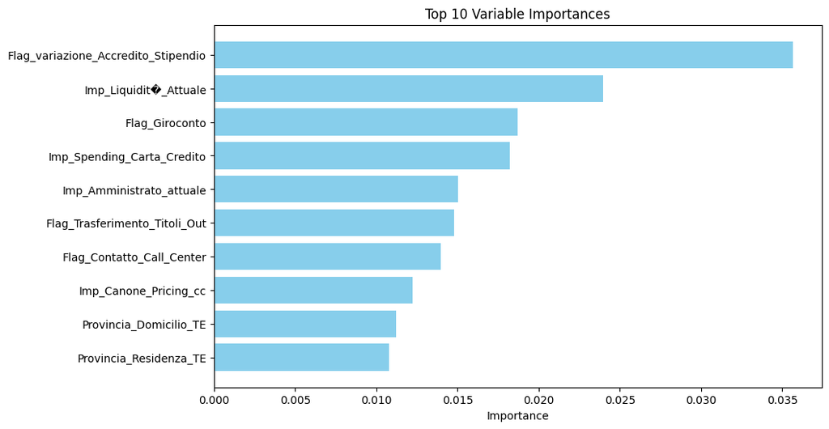

```python
importance = best_xgb_classifier.feature_importances_
features = X_train_final.columns
importance_df = pd.DataFrame({'Feature': features, 'Importance': importance})
importance_df = importance_df.sort_values(by='Importance', ascending=False)

plt.figure(figsize=(10, 6))
plt.barh(importance_df['Feature'].head(10), importance_df['Importance'].head(10), color='skyblue')
plt.xlabel('Importance')
plt.title('Top 10 Variable Importances')
plt.gca().invert_yaxis()
plt.show()
```

###### Results

```python
results_df = pd.DataFrame({
    'y_test': y_test_final,
    'y_pred_proba': xgb_predictions

})

results_df_si = results_df
results_df_si_sorted = results_df_si.sort_values(by='y_pred_proba', ascending=False)
top_10000_si = results_df_si_sorted.head(4000)
print(top_10000_si)
```

```
        y_test  y_pred_proba
288850       0      0.998611
91629        0      0.998292
17678        1      0.998095
236314       0      0.997816
257262       0      0.997811
...        ...           ...
99600        0      0.762464
218598       0      0.762450
61735        0      0.762420
306566       0      0.762387
263941       0      0.762372

[4000 rows x 2 columns]
```

```python
count_si = top_10000_si[top_10000_si['y_test'] == 1].shape[0]

print("Numero di 'SI' nei nostri 10k:", count_si)
count_ones = np.sum(y_test == 1)

print("Numero di 'SI: nel nostro test set", count_ones)
```

```
Numero di 'SI' nei nostri 10k: 230
Numero di 'SI: nel nostro test set 393
```

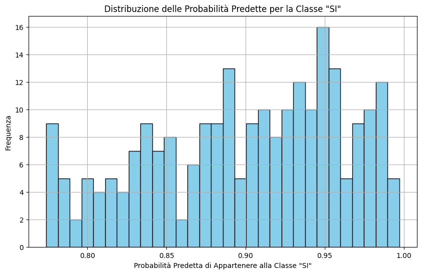

```python
plt.figure(figsize=(10, 6))
plt.hist( top_10000_si[top_10000_si['y_test'] == 1]['y_pred_proba'], bins=30, color='skyblue', edgecolor='black')
plt.title('Distribuzione delle Probabilità Predette per la Classe "SI"')
plt.xlabel('Probabilità Predetta di Appartenere alla Classe "SI"')
plt.ylabel('Frequenza')
plt.grid(True)
plt.show()
```

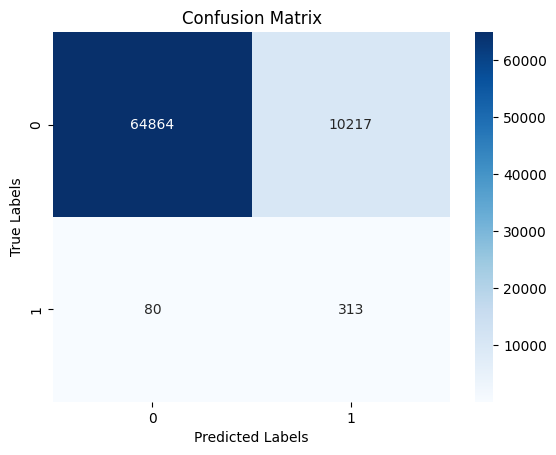

```python
y_pred = best_xgb_classifier.predict(X_test_final)

cm = confusion_matrix(y_test_final, y_pred)
sns.heatmap(cm, annot=True, fmt="d", cmap='Blues')
plt.xlabel('Predicted Labels')
plt.ylabel('True Labels')
plt.title('Confusion Matrix')
plt.show()
```

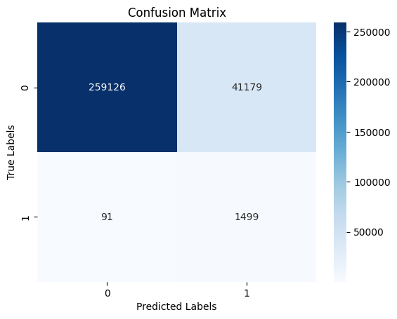

```python
y_pred = best_xgb_classifier.predict(X_train_final)

cm = confusion_matrix(y_train_final, y_pred)
sns.heatmap(cm, annot=True, fmt="d", cmap='Blues')
plt.xlabel('Predicted Labels')
plt.ylabel('True Labels')
plt.title('Confusion Matrix')
plt.show()
```

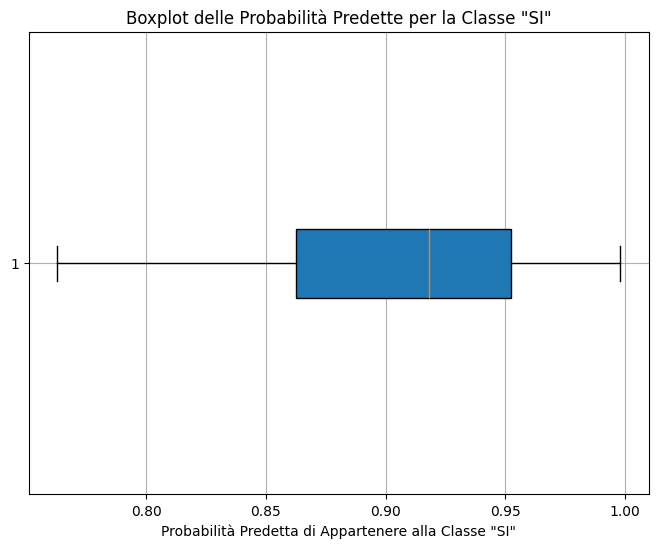

```python
plt.figure(figsize=(8, 6))
plt.boxplot( top_10000_si[top_10000_si['y_test'] == 1]['y_pred_proba'],vert=False, patch_artist=True)
plt.title('Boxplot delle Probabilità Predette per la Classe "SI"')
plt.xlabel('Probabilità Predetta di Appartenere alla Classe "SI"')
plt.grid(True)
plt.show()
```

###### It's important to verify if the model is in overfittting. Through the use of the learning curve, we can see in the trained data and the tested data converge: if this happen, the model can summarize good the data, without overfitting. If the two curves remain far, there could be the overfitting risk. The metric used for the comparison is the Recall.

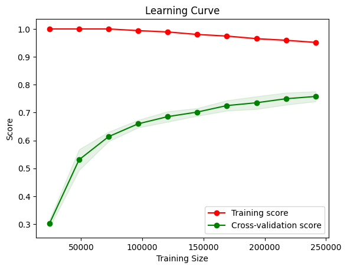

```python
train_sizes, train_scores, test_scores = learning_curve(best_xgb_classifier, X_train_final, y_train_final, cv=5, scoring='recall', n_jobs=-1, train_sizes=np.linspace(0.1, 1.0, 10))
train_mean = np.mean(train_scores, axis=1)
train_std = np.std(train_scores, axis=1)
test_mean = np.mean(test_scores, axis=1)
test_std = np.std(test_scores, axis=1)

plt.fill_between(train_sizes, train_mean - train_std, train_mean + train_std, color='r', alpha=0.1)
plt.fill_between(train_sizes, test_mean - test_std, test_mean + test_std, color='g', alpha=0.1)
plt.plot(train_sizes, train_mean, 'o-', color='r', label='Training score')
plt.plot(train_sizes, test_mean, 'o-', color='g', label='Cross-validation score')
plt.xlabel('Training Size')
plt.ylabel('Score')
plt.title('Learning Curve')
plt.legend(loc="best")
plt.show()
```

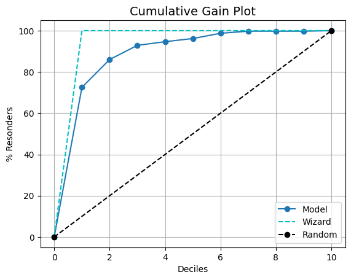

```python
import kds
kds.metrics.plot_cumulative_gain(y_test_final, xgb_predictions)
```

##### XGBoost on the syntetic dataset

```python
X_train_res_synthetic.rename(columns={
    'Professione_Libero professionista/Titolare impresa': 'Professione_Libero_professionista/Titolare_impresa'
}, inplace=True)
#missmatch between column_names
```

```python
xgb_predictions = best_xgb_classifier.predict_proba(X_train_res_synthetic)[:, 1]
results_df = pd.DataFrame({
    'y_test': y_synthetic,
    'y_pred_proba': xgb_predictions

})

results_df_si = results_df
results_df_si_sorted = results_df_si.sort_values(by='y_pred_proba', ascending=False)
top_10000_si_synthetic = results_df_si_sorted.head(4000)
print(top_10000_si_synthetic)
```

```
       y_test  y_pred_proba
20713       0      0.950189
41056       0      0.949418
44462       0      0.947188
62547       0      0.938932
6352        0      0.917699
...       ...           ...
42430       0      0.382303
52911       0      0.382288
26333       0      0.382212
54782       0      0.382170
21373       0      0.382144

[4000 rows x 2 columns]
```

```python
count_si = top_10000_si_synthetic[top_10000_si_synthetic['y_test'] == 1].shape[0]

print("Numero di 'SI' nei nostri 10k:", count_si)
count_ones = np.sum(y_synthetic == 1)

print("Numero di 'SI: nel nostro test set", count_ones)
```

```
Numero di 'SI' nei nostri 10k: 55
Numero di 'SI: nel nostro test set 489
```

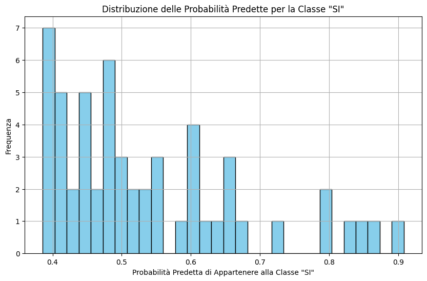

```python
plt.figure(figsize=(10, 6))
plt.hist( top_10000_si_synthetic[top_10000_si_synthetic['y_test'] == 1]['y_pred_proba'], bins=30, color='skyblue', edgecolor='black')
plt.title('Distribuzione delle Probabilità Predette per la Classe "SI"')
plt.xlabel('Probabilità Predetta di Appartenere alla Classe "SI"')
plt.ylabel('Frequenza')
plt.grid(True)
plt.show()
```

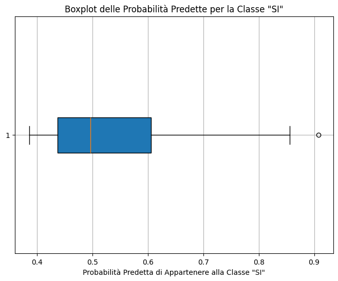

```python
plt.figure(figsize=(8, 6))
plt.boxplot( top_10000_si_synthetic[top_10000_si_synthetic['y_test'] == 1]['y_pred_proba'],vert=False, patch_artist=True)
plt.title('Boxplot delle Probabilità Predette per la Classe "SI"')
plt.xlabel('Probabilità Predetta di Appartenere alla Classe "SI"')
plt.grid(True)
plt.show()
```

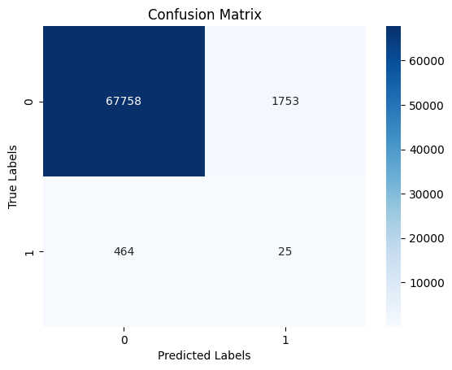

```python
y_pred = best_xgb_classifier.predict(X_train_res_synthetic)

cm = confusion_matrix(y_synthetic, y_pred)
sns.heatmap(cm, annot=True, fmt="d", cmap='Blues')
plt.xlabel('Predicted Labels')
plt.ylabel('True Labels')
plt.title('Confusion Matrix')
plt.show()
```

#### Third Alghoritm: Catboost

```python
def objective(trial):
    X_train, X_test, y_train, y_test = train_test_split(X, y, test_size=0.2, random_state=1)
    XX = pd.get_dummies(pd.concat([X_train, X_test], sort=False))
    X_train, X_test = XX.loc[X_train.index], XX.loc[X_test.index]

    X_train = clean_feature_names(X_train)
    X_test = clean_feature_names(X_test)

    X_train, X_test = X_train.align(X_test, join='inner', axis=1)

    scale_pos_weight = len(y[y == 0]) / len(y[y == 1])

    params = {
        'n_estimators': trial.suggest_int('n_estimators', 100, 500),
        'learning_rate': trial.suggest_float('learning_rate', 0.01, 0.2, log=True),
        'max_depth': trial.suggest_int('max_depth', 5, 15),
        'l2_leaf_reg': trial.suggest_float('l2_leaf_reg', 1e-3, 10),
        'border_count': trial.suggest_int('border_count', 32, 255),
        'grow_policy': trial.suggest_categorical('grow_policy', ['SymmetricTree', 'Depthwise', 'Lossguide']),
        'min_data_in_leaf': trial.suggest_int('min_data_in_leaf', 1, 50),
        'leaf_estimation_iterations': trial.suggest_int('leaf_estimation_iterations', 1, 10),
        'leaf_estimation_method': trial.suggest_categorical('leaf_estimation_method', ['Newton', 'Gradient']),
        'scale_pos_weight': scale_pos_weight,
        'verbose': False
    }

    kf = StratifiedKFold(n_splits=10, shuffle=True, random_state=42)
    scores = []

    for train_index, val_index in kf.split(X_train, y_train):
        X_fold_train, X_fold_val = X_train.iloc[train_index], X_train.iloc[val_index]
        y_fold_train, y_fold_val = y_train.iloc[train_index], y_train.iloc[val_index]

        model = cb.CatBoostClassifier(**params)
        model.fit(X_fold_train, y_fold_train)
        probas = model.predict_proba(X_fold_val)[:, 1]
        top_indices = np.argsort(probas)[-1698:]
        top_positives = y_fold_val.iloc[top_indices].sum()
        total_positives = y_fold_val.sum()
        scores.append(top_positives / total_positives if total_positives > 0 else 0)

    return np.mean(scores)

sampler = optuna.samplers.TPESampler(seed=42)
study = optuna.create_study(direction='maximize', sampler=sampler)
study.optimize(objective, n_trials=50)

best_params = study.best_params
best_score = study.best_value

print("Best Hyperparameters:", best_params)
print("Best Score for Top 50,000:", best_score)


history_plot = vis.plot_optimization_history(study)
history_plot.show()

importance_plot = vis.plot_param_importances(study)
importance_plot.show()

slice_plot = vis.plot_slice(study)
slice_plot.show()
```

```
[I 2024-05-08 20:02:11,662] A new study created in memory with name: no-name-9103109e-f0e4-4ae4-a6a1-9c5578608dea
```

```
[I 2024-05-08 20:08:16,044] Trial 0 finished with value: 0.5647798742138366 and parameters: {'n_estimators': 250, 'learning_rate': 0.17254716573280354, 'max_depth': 13, 'l2_leaf_reg': 5.986986183486169, 'border_count': 66, 'grow_policy': 'Lossguide', 'min_data_in_leaf': 31, 'leaf_estimation_iteratio…
[I 2024-05-08 20:10:58,664] Trial 1 finished with value: 0.5245283018867924 and parameters: {'n_estimators': 433, 'learning_rate': 0.018891200276189388, 'max_depth': 7, 'l2_leaf_reg': 1.8348616940244846, 'border_count': 100, 'grow_policy': 'SymmetricTree', 'min_data_in_leaf': 31, 'leaf_estimation_it…
[I 2024-05-08 20:14:36,503] Trial 2 finished with value: 0.5339622641509434 and parameters: {'n_estimators': 282, 'learning_rate': 0.10508421338691762, 'max_depth': 7, 'l2_leaf_reg': 5.142830149697703, 'border_count': 164, 'grow_policy': 'Depthwise', 'min_data_in_leaf': 4, 'leaf_estimation_iteration…
[I 2024-05-08 20:18:16,673] Trial 3 finished with value: 0.5188679245283019 and parameters: {'n_estimators': 222, 'learning_rate': 0.013399060561509796, 'max_depth': 12, 'l2_leaf_reg': 4.402084784902274, 'border_count': 59, 'grow_policy': 'Lossguide', 'min_data_in_leaf': 13, 'leaf_estimation_iterati…
[I 2024-05-08 20:22:44,751] Trial 4 finished with value: 0.5056603773584906 and parameters: {'n_estimators': 319, 'learning_rate': 0.017398074711291726, 'max_depth': 15, 'l2_leaf_reg': 7.751553100787786, 'border_count': 242, 'grow_policy': 'Lossguide', 'min_data_in_leaf': 5, 'leaf_estimation_iterati…
[I 2024-05-08 20:27:16,411] Trial 5 finished with value: 0.5572327044025157 and parameters: {'n_estimators': 255, 'learning_rate': 0.022544116997360492, 'max_depth': 14, 'l2_leaf_reg': 3.5681765136091994, 'border_count': 94, 'grow_policy': 'Lossguide', 'min_data_in_leaf': 4, 'leaf_estimation_iterati…
[I 2024-05-08 20:30:02,289] Trial 6 finished with value: 0.5132075471698113 and parameters: {'n_estimators': 102, 'learning_rate': 0.11506408247250169, 'max_depth': 12, 'l2_leaf_reg': 7.290342673241833, 'border_count': 204, 'grow_policy': 'Depthwise', 'min_data_in_leaf': 44, 'leaf_estimation_iterati…
[I 2024-05-08 20:33:43,250] Trial 7 finished with value: 0.5591194968553459 and parameters: {'n_estimators': 224, 'learning_rate': 0.026489469207362663, 'max_depth': 13, 'l2_leaf_reg': 6.375937156080776, 'border_count': 230, 'grow_policy': 'Lossguide', 'min_data_in_leaf': 39, 'leaf_estimation_iterat…
[I 2024-05-08 20:35:22,232] Trial 8 finished with value: 0.5490566037735849 and parameters: {'n_estimators': 309, 'learning_rate': 0.035995125264172326, 'max_depth': 5, 'l2_leaf_reg': 1.0798063785060512, 'border_count': 39, 'grow_policy': 'SymmetricTree', 'min_data_in_leaf': 46, 'leaf_estimation_ite…
[I 2024-05-08 20:38:12,405] Trial 9 finished with value: 0.5289308176100629 and parameters: {'n_estimators': 191, 'learning_rate': 0.012593695017526326, 'max_depth': 8, 'l2_leaf_reg': 1.6130516512527902, 'border_count': 240, 'grow_policy': 'Lossguide', 'min_data_in_leaf': 41, 'leaf_estimation_iterat…
[I 2024-05-08 20:44:59,382] Trial 10 finished with value: 0.5163522012578616 and parameters: {'n_estimators': 411, 'learning_rate': 0.1635616352001945, 'max_depth': 10, 'l2_leaf_reg': 9.322971128775963, 'border_count': 121, 'grow_policy': 'Depthwise', 'min_data_in_leaf': 22, 'leaf_estimation_iterati…
[I 2024-05-08 20:47:24,457] Trial 11 finished with value: 0.570440251572327 and parameters: {'n_estimators': 150, 'learning_rate': 0.05524904408647626, 'max_depth': 13, 'l2_leaf_reg': 6.181862381618724, 'border_count': 166, 'grow_policy': 'Lossguide', 'min_data_in_leaf': 32, 'leaf_estimation_iterati…
[I 2024-05-08 20:49:08,031] Trial 12 finished with value: 0.5459119496855347 and parameters: {'n_estimators': 118, 'learning_rate': 0.060229644449620666, 'max_depth': 11, 'l2_leaf_reg': 6.075216579052612, 'border_count': 168, 'grow_policy': 'Lossguide', 'min_data_in_leaf': 27, 'leaf_estimation_itera…
[I 2024-05-08 20:51:45,684] Trial 13 finished with value: 0.5628930817610063 and parameters: {'n_estimators': 171, 'learning_rate': 0.06177730157761027, 'max_depth': 15, 'l2_leaf_reg': 9.993625023976875, 'border_count': 143, 'grow_policy': 'Lossguide', 'min_data_in_leaf': 34, 'leaf_estimation_iterat…
```

[output cut: 36 more lines]

```
Best Hyperparameters: {'n_estimators': 329, 'learning_rate': 0.05194348975504665, 'max_depth': 14, 'l2_leaf_reg': 7.9578314783147945, 'border_count': 188, 'grow_policy': 'Lossguide', 'min_data_in_leaf': 29, 'leaf_estimation_iterations': 6, 'leaf_estimation_method': 'Gradient'}
Best Score for Top 50,000: 0.5830188679245283
```

```python
'''
Best Hyperparameters: {'n_estimators': 486, 'learning_rate': 0.08564115269968339, 'max_depth': 5, 'l2_leaf_reg': 5.495063193351241, 'border_count': 113, 'grow_policy': 'SymmetricTree', 'min_data_in_leaf': 8, 'leaf_estimation_iterations': 9, 'leaf_estimation_method': 'Gradient'}
Best Score for Top 50,000: 0.8327044025157233
'''
scale_pos_weight = len(y[y == 0]) / len(y[y == 1])

catboost_params = {
    'n_estimators': 329,
    'learning_rate': 0.05194348975504665,
    'max_depth': 14,
    'l2_leaf_reg': 7.9578314783147945,
    'border_count': 188,
    'grow_policy': 'Lossguide',
    'min_data_in_leaf': 29,
    'leaf_estimation_iterations': 6,
    'leaf_estimation_method': 'Gradient',
    'scale_pos_weight': scale_pos_weight,
}

best_catboost_classifier = cb.CatBoostClassifier(**catboost_params)

best_catboost_classifier.fit(X_train_final, y_train_final)
catboost_predictions = best_catboost_classifier.predict_proba(X_test_final)[:, 1]
```

[output not shown]

[output cut: 274 more lines]

[output not shown]

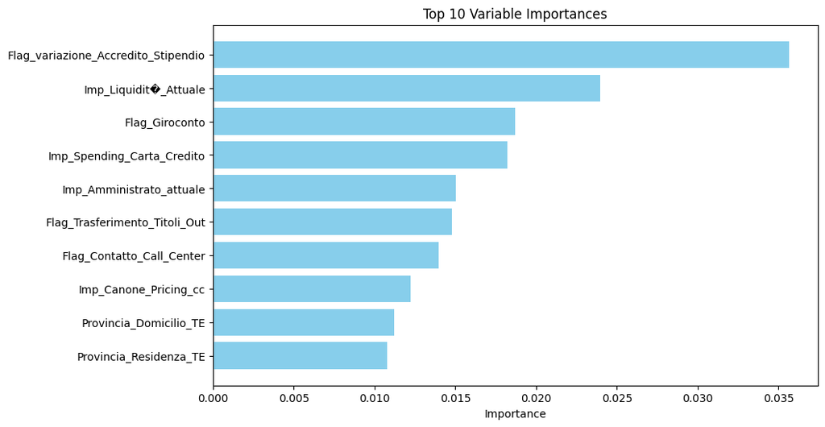

```python
importance = best_xgb_classifier.feature_importances_
features = X_train_final.columns
importance_df = pd.DataFrame({'Feature': features, 'Importance': importance})
importance_df = importance_df.sort_values(by='Importance', ascending=False)

plt.figure(figsize=(10, 6))
plt.barh(importance_df['Feature'].head(10), importance_df['Importance'].head(10), color='skyblue')
plt.xlabel('Importance')
plt.title('Top 10 Variable Importances')
plt.gca().invert_yaxis()  # Invert y-axis to have the most important at the top
plt.show()
```

```python
results_df = pd.DataFrame({
    'y_test': y_test_final,
    'y_pred_proba': catboost_predictions

})

results_df_si = results_df
results_df_si_sorted = results_df_si.sort_values(by='y_pred_proba', ascending=False)
top_10000_si = results_df_si_sorted.head(4000)
print(top_10000_si)
```

```
        y_test  y_pred_proba
288850       0      0.988678
91629        0      0.986011
25853        1      0.985830
117164       0      0.984374
17678        1      0.983631
...        ...           ...
164166       0      0.760716
172759       0      0.760694
48330        0      0.760683
298809       0      0.760618
345245       0      0.760567

[4000 rows x 2 columns]
```

```python
count_si = top_10000_si[top_10000_si['y_test'] == 1].shape[0]

print("Numero di 'SI' nei nostri 10k:", count_si)
count_ones = np.sum(y_test == 1)

print("Numero di 'SI: nel nostro test set", count_ones)
```

```
Numero di 'SI' nei nostri 10k: 237
Numero di 'SI: nel nostro test set 393
```

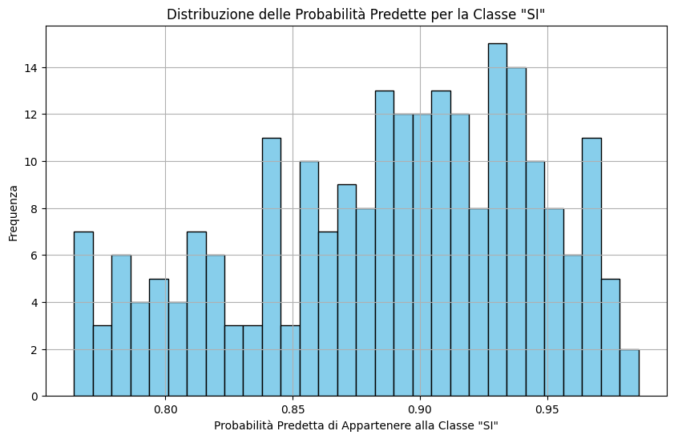

```python
plt.figure(figsize=(10, 6))
plt.hist( top_10000_si[top_10000_si['y_test'] == 1]['y_pred_proba'], bins=30, color='skyblue', edgecolor='black')
plt.title('Distribuzione delle Probabilità Predette per la Classe "SI"')
plt.xlabel('Probabilità Predetta di Appartenere alla Classe "SI"')
plt.ylabel('Frequenza')
plt.grid(True)
plt.show()
```

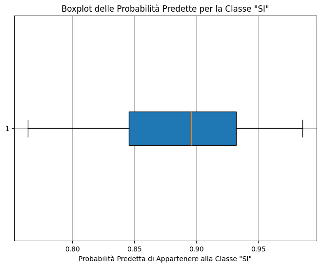

```python
plt.figure(figsize=(8, 6))
plt.boxplot( top_10000_si[top_10000_si['y_test'] == 1]['y_pred_proba'],vert=False, patch_artist=True)
plt.title('Boxplot delle Probabilità Predette per la Classe "SI"')
plt.xlabel('Probabilità Predetta di Appartenere alla Classe "SI"')
plt.grid(True)
plt.show()
```